# Time Series: A First Course with Bootstrap Starter

# Lesson 7-3: Spectral Representation

We discuss a representation of a stationary time series as a sum of stochastic cosines.

## Definition 7.3.1.

- For a given spectral distribution $F$, a **spectral increment process** $Z$ is a complex-valued continuous-time stochastic process defined on the interval $[-\pi, \pi]$, which has mean zero with *orthogonal increments*: for $\lambda_1 < \lambda_2 < \lambda_3 < \lambda_4$, the random variables $Z(\lambda_2) - Z(\lambda_1)$ and $Z(\lambda_4) - Z (\lambda_3)$ are orthogonal. Also,
  $$\mbox{Var} [ Z(\lambda_2) - Z(\lambda_1)] = \frac{1}{2 \pi}
  \left( F(\lambda_2) - F (\lambda_1) \right).$$
- The variance of a complex random variable is the expectation of its squared modulus.
- We abbreviate the above expression by
  $$\mbox{Var} [ dZ (\lambda) ] = \frac{1}{2 \pi} dF (\lambda) .$$

## Paradigm 7.3.4. Time Series Defined as a Stochastic Integral

- We can define a time series via a stochastic integral as follows:
  $$X_t = \int_{-\pi}^{\pi} e^{i \lambda t} dZ (\lambda).$$
- This resembles a sum of stochastic cosines, where $dZ(\lambda)$ is the amplitude for a sinusoid $e^{i \lambda t}$.
- Then $\{ X_t \}$ has mean zero and autocovariance
  $$\mbox{Cov} [ X_{t+h}, {X}_t ] =
  \int_{-\pi}^{\pi} \int_{-\pi}^{\pi} e^{i \lambda (t+h)} e^{-i \omega t}
  \mbox{Cov} [ dZ(\lambda), dZ(\omega)]
  = \frac{1}{2 \pi} \int_{-\pi}^{\pi} e^{i \lambda h } dF (\lambda).$$
- So $\{ X_t \}$ is weakly stationary with ACVF $\gamma (h)$ given by above formula.
- Conversely: any mean zero weakly stationary time series $\{ X_t \}$ with spectral distribution function $F$ can be represented by the above stochastic integral!

## Corollary 7.3.8.

- Suppose $\{ X_t \}$ is a mean zero weakly stationary time series with spectral representation, and let $Y_t = \psi (B) X_t$. Then
  $$Y_t = \sum_j \psi_j X_{t-j} = \sum_j \psi_j \int_{-\pi}^{\pi} e^{i
  \lambda (t-j)} dZ(\lambda)
  = \int_{-\pi}^{\pi} \sum_j \psi_j e^{-i\lambda j} e^{i \lambda t}
  dZ(\lambda) =
  \int_{-\pi}^{\pi} \psi(e^{-i \lambda}) e^{i \lambda t} dZ (\lambda).$$
- So $\{ Y_t \}$ also has a spectral representation, but its increment process is $\psi (e^{-i \lambda}) dZ (\lambda)$, where $\psi (e^{-i \lambda})$ is the filter frequency response function. We can use this result to understand the impact of a filter in the frequency domain.
- The ACVF is
  $$\mbox{Cov} [ Y_{t+h}, Y_t] = \frac{1}{2 \pi} \int_{-\pi}^{\pi} e^{i
  \lambda h}
  {| \psi (e^{-i \lambda} ) |}^2 dF (\lambda).$$

## Example 7.3.10. Time Shift

- Consider $\psi (B) = B^k$, a shift by $k$ time units. Then $\psi(e^{-i \lambda}) = e^{-i \lambda k}$ and $Y_t = \int_{-\pi}^{\pi } e^{i \lambda (t-k)} dZ(\lambda)$.
- This is the same as $B^k X_t = X_{t-k}$.

## Fact 7.3.12. Action of Phase Delay.

- From Corollary 7.3.8,
  $$Y_t = \int_{-\pi}^{\pi} e^{i (\lambda t + \mbox{Arg} \psi(e^{-i
  \lambda}) ) } |\psi(e^{-i \lambda})| dZ (\lambda)
  = \int_{-\pi}^{\pi} e^{i \lambda (t - \Upsilon (\lambda) ) }
  |\psi(e^{-i \lambda})| dZ (\lambda).$$
- So at frequency $\lambda$, time $t$ is delayed by $\Upsilon (\lambda)$ time units.
- Also, the gain modifies the autocovariances.

## Example 7.3.13. Simple Moving Average Filters Cause Delay

- Consider the simple moving average filter $\psi (B) = (1 + B + B^2)/3$, which gives the average of the past and present $3$ observations.
- We directly compute the frequency response function:
  $$\psi(e^{-i \lambda}) = \frac{1 + e^{-i \lambda} + e^{-i 2 \lambda}}{3}
  = e^{-i \lambda} \, \frac{e^{i \lambda} + 1 + e^{-i \lambda}}{3}
  = e^{-i \lambda} \, \frac{1 + 2 \cos (\lambda)}{3}.$$
- The gain function is
  $$\frac{1}{3} | 1 + 2 \cos (\lambda) |.$$
- Note that $1 + 2 \cos (\lambda)$ is non-negative for $\lambda \in [0, 2 \pi/3]$, so the phase function equals $-\lambda$ over that set. Otherwise, we need a $-1$ factor which leads to a phase function equal to $-\lambda - \pi$.
- The phase delay function is then
  $$\Upsilon (\lambda) = \begin{cases} 1 \quad \mbox{if} \; \lambda \in [0,
  2 \pi/3] \\
  1 + \pi/\lambda \quad \mbox{else}. \end{cases}$$
- Since this function is positive, the filter always provides a delay.
- The gain function attenuates higher frequencies, due to the cosine shape, so the filter is a “low-pass.”

## Exercise 7.29. Phase and Gain for Simple Moving Average.

- Consider the simple moving average of order $p$: $\psi (B) = {(2p+1)}^{-1} \sum_{j=-p}^p B^j$.
- It can be shown that
  $$\psi(e^{-i \lambda}) = \frac{ \sin (\lambda (p+1/2))}{ (2p+1) \sin
  (\lambda/2)}$$
- We use this formula to encode and display the gain and phase functions, as well as the real and imaginary parts of the frequency response function.

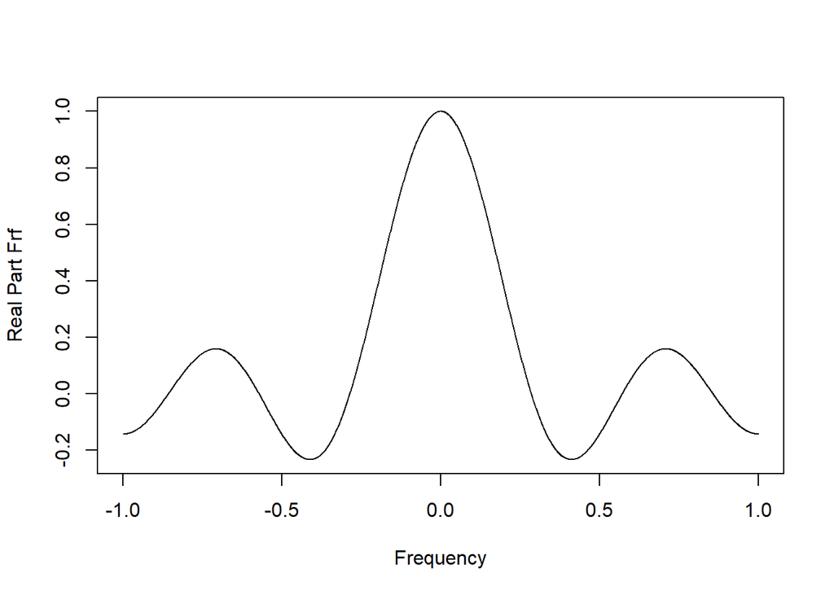

```r
lambda <- pi*seq(-1000,1000)/1000
p <- 3
simplema.frf <- sin((p+1/2)*lambda)/((2*p+1)*sin(lambda/2))
simplema.gain <- Mod(simplema.frf)
simplema.phase <- atan(Im(simplema.frf)/Re(simplema.frf))
simplema.delay <- -1*simplema.phase/lambda
plot(ts(Re(simplema.frf),start=-1,frequency=1000),
    xlab="Frequency",ylab="Real Part Frf")
```

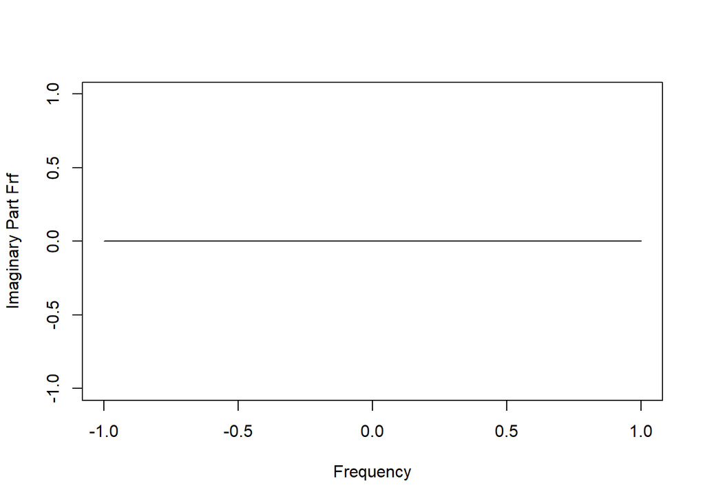

```r
plot(ts(Im(simplema.frf),start=-1,frequency=1000),
    xlab="Frequency",ylab="Imaginary Part Frf")
```

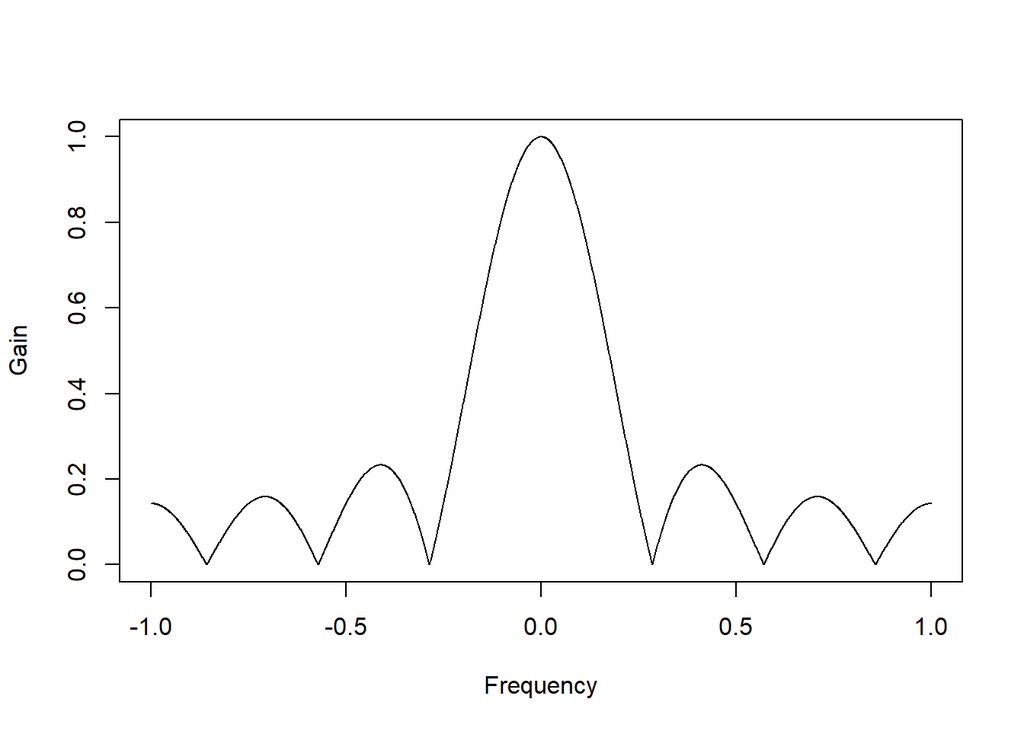

```r
plot(ts(simplema.gain,start=-1,frequency=1000),
    xlab="Frequency",ylab="Gain")
```

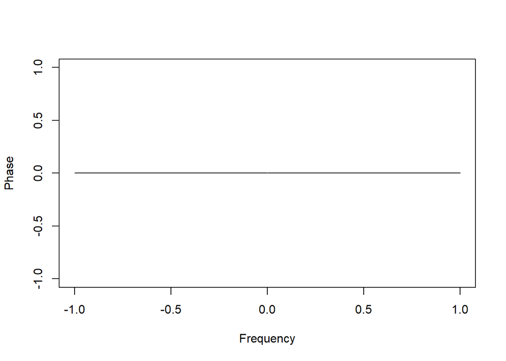

```r
plot(ts(simplema.phase,start=-1,frequency=1000),
    xlab="Frequency",ylab="Phase")
```

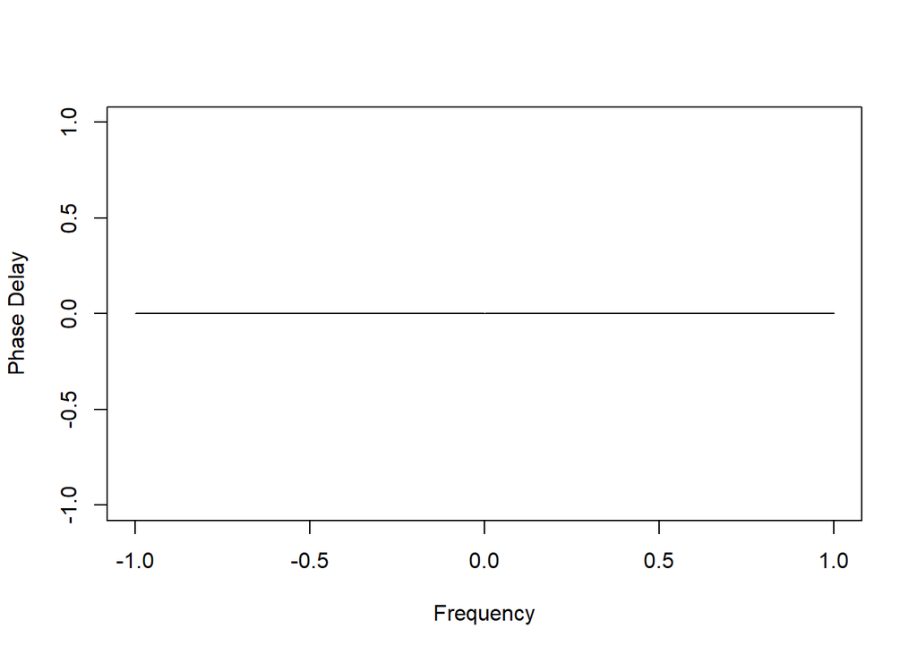

```r
plot(ts(simplema.delay,start=-1,frequency=1000),
    xlab="Frequency",ylab="Phase Delay")
```

## Exercise 7.30. Phase and Gain for Seasonal Aggregation Filter.

- Consider the seasonal aggregation filter: $\psi (B) = \sum_{j=0}^{s-1} B^j$.
- We encode and display the gain and phase functions, as well as the real and imaginary parts of the frequency response function.

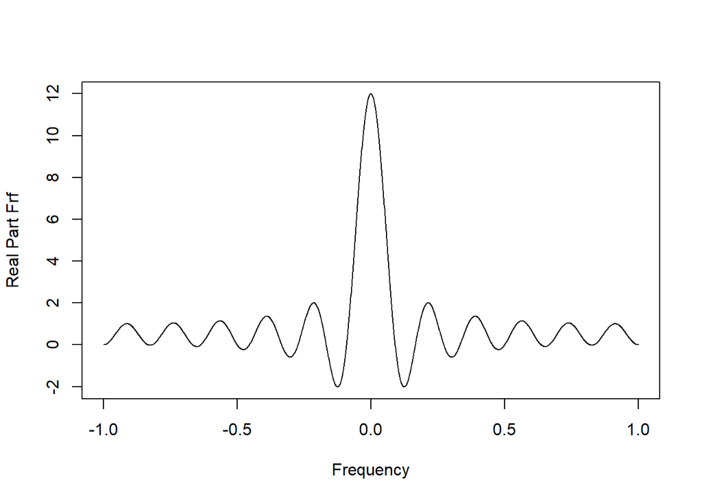

```r
lambda <- pi*seq(-1000,1000)/1000
s <- 12
seasagg.frf <- exp(-1i*lambda*(s-1)/2)*sin((s/2)*lambda)/sin(lambda/2)
seasagg.gain <- Mod(seasagg.frf)
seasagg.phase <- atan(Im(seasagg.frf)/Re(seasagg.frf))
seasagg.delay <- -1*seasagg.phase/lambda
seasagg.delay[1001] <- NA
plot(ts(Re(seasagg.frf),start=-1,frequency=1000),
    xlab="Frequency",ylab="Real Part Frf")
```

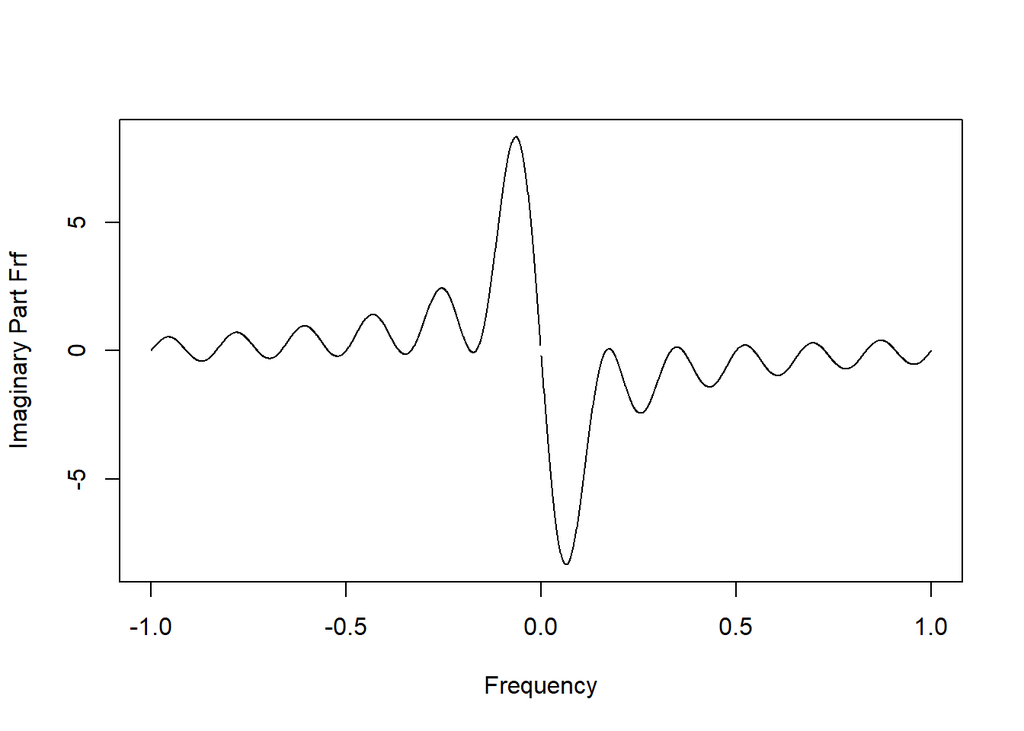

```r
plot(ts(Im(seasagg.frf),start=-1,frequency=1000),
    xlab="Frequency",ylab="Imaginary Part Frf")
```

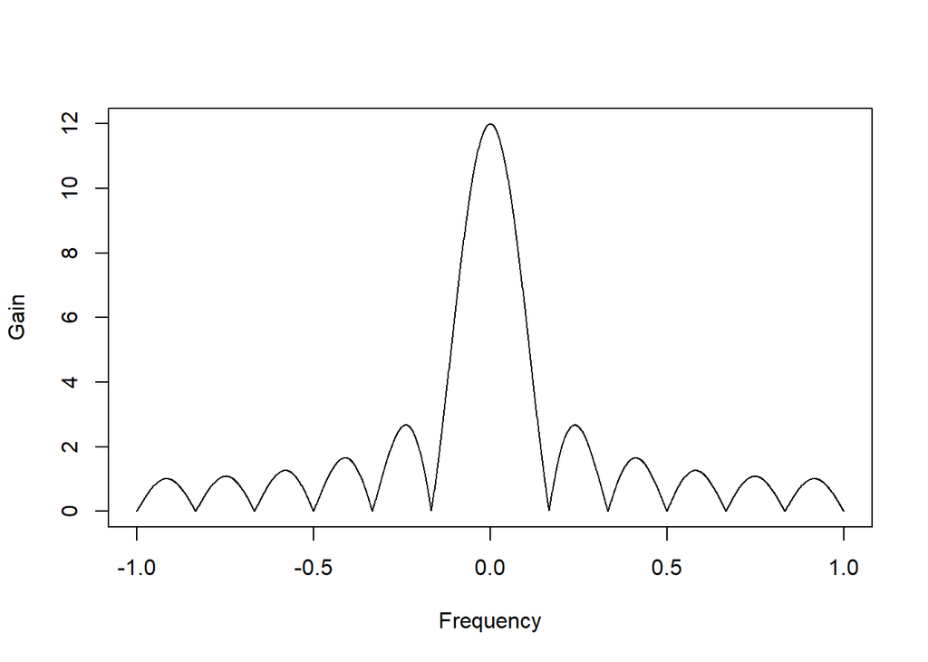

```r
plot(ts(seasagg.gain,start=-1,frequency=1000),
    xlab="Frequency",ylab="Gain")
```

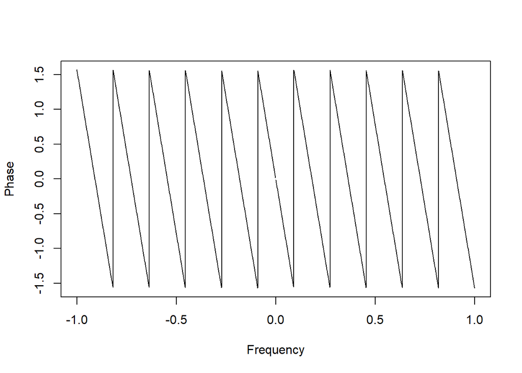

```r
plot(ts(seasagg.phase,start=-1,frequency=1000),
    xlab="Frequency",ylab="Phase")
```

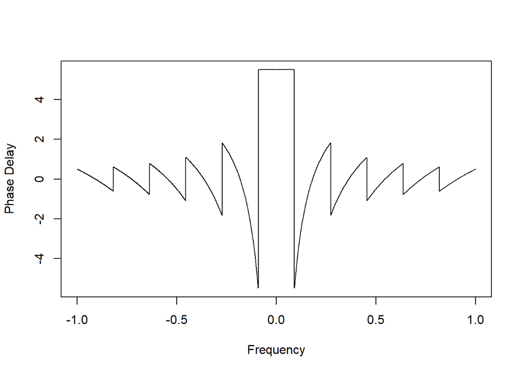

```r
plot(ts(seasagg.delay,start=-1,frequency=1000),
    xlab="Frequency",ylab="Phase Delay")
```